# Class 4 - plotting basics

Author

Szymon Drobniak

Published

December 1, 2024

**Before you start…**

Make sure you have the following set and ready:

- Folder you want touse as your working directory exists on your HDD
- Set this folder as working directory (using a menu or `setwd("YOUR_PATH)`)
- Relevant data (if provided) is in your working directory

**In the below instructions…**

**EXERCISE X:** are bits of code to execute/practice pieces to do, often with only hints on how to perform them.

**Output** indicates the typical output you should expect from a given instruction.

**Data**

We will work on a simple dataset on cholesterol levels from patients. The data presents cholesterol concentrations in plasma in patients before diet, and after 4 & 8 weeks of diet containing one of two types of margarine. The age group of patients is also indicated. Data can be downloaded here: https://raw.githubusercontent.com/wbabik/Practical_computing/teaching/Class_10/data/Cholesterol_Age_R.csv

```r
data_chol <- read.table("https://raw.githubusercontent.com/wbabik/Practical_computing/teaching/Class_10/data/Cholesterol_Age_R.csv",
    sep = ";", header = T,
    stringsAsFactors = T
)

head(data_chol)
```

```
  ID Before After4weeks After8weeks Margarine AgeGroup
1  1   6.42        5.83        5.75         B    Young
2  2   6.76        6.20        6.13         A    Young
3  3   6.56        5.83        5.71         B    Young
4  4   4.80        4.27        4.15         A    Young
5  5   8.43        7.71        7.67         B    Young
6  6   7.49        7.12        7.05         A   Middle
```

```r
summary(data_chol)
```

```
       ID            Before       After4weeks     After8weeks    Margarine
 Min.   : 1.00   Min.   :3.910   Min.   :3.700   Min.   :3.660   A:9
 1st Qu.: 5.25   1st Qu.:5.740   1st Qu.:5.175   1st Qu.:5.210   B:9
 Median : 9.50   Median :6.500   Median :5.830   Median :5.730
 Mean   : 9.50   Mean   :6.408   Mean   :5.842   Mean   :5.779
 3rd Qu.:13.75   3rd Qu.:7.218   3rd Qu.:6.730   3rd Qu.:6.688
 Max.   :18.00   Max.   :8.430   Max.   :7.710   Max.   :7.670
   AgeGroup
 Middle:6
 Old   :7
 Young :5
```

## 1 Formula notation

R modelling and graphing functions use a particular type of notation, originating from the S-PLUS language, to represent relationships between variables. Proportionality in this notation is indicated by `~`, left-hand-side (LHS) of the formula contains dependent variables, right-hand-side (RHS) independent. E.g., `y ~ x + z` may be used to write down a relationship between a measured `y` variable and two independent variables (`x` and `z`). Simple formulas (one LHS and one RHS variable) are covenietnly used to assign variables to axes of a plot.

## 2 Simple R plot

First…

> *It is a myth that R is incapable of producing a final, publication quality (and pretty!) plot that would not have to be modified afterwards :)*

To represent data graphically we have to asign it to the proper plot axis. The simplest way of plotting data in R is by using a built-in function `plot()`. Variables to plot can be supplied as its arguments, respectively as **x** (horizontal axis) i **y** (vertical axis) - or by supplying one argument, a formula, describing the relationship between the dependent and independent variable, or in other words between x & y as `y ~ x`. Have a look into `?plot()` to learn more. Note, that - depending on the situation - you may have to provide just variable names together with the name of the dataset - using `data = ...` - or to directly call variables in your dataset (e.g. by using `...$variable_x`).

**EXERCISE 1:**Try to recreate the below plot using the loaded data. Consult the `plot()` function if necessary.

**Output**

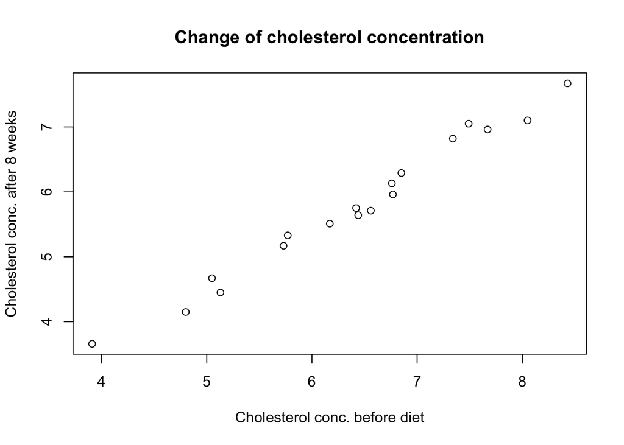

```r
plot(After8weeks ~ Before, data = data_chol,
xlab = "Cholesterol conc. before diet",
ylab = "Cholesterol conc. after 8 weeks",
main = "Change of cholesterol concentration")
```

```r
### OR

# plot(x = data_chol$Before, y = data_chol$After8weeks,
# xlab = "Cholesterol conc. before diet",
# ylab = "Cholesterol conc. after 8 weeks",
# main = "Change of cholesterol concentration")
```

**EXERCISE 2:** Modify the plot changing the shapes and colours used on the plot (hints can be found here: https://www.r-graph-gallery.com/6-graph-parameters-reminder.html). Here I’m setting the symbols as blue squares.

**Output**

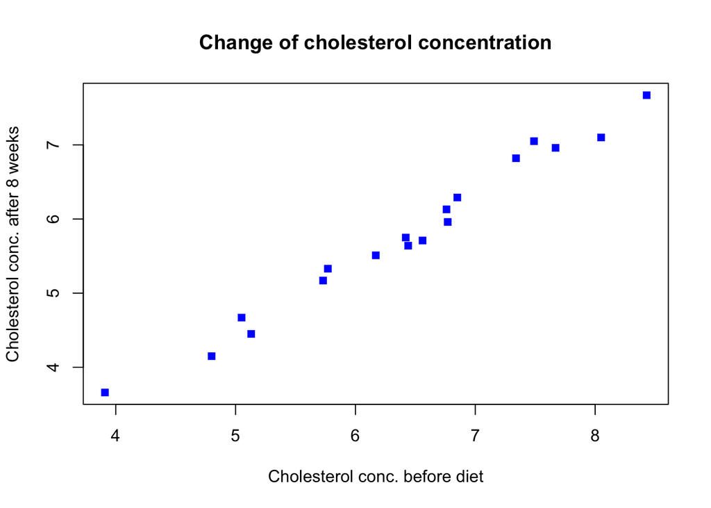

```r
plot(After8weeks ~ Before, data = data_chol,
xlab = "Cholesterol conc. before diet",
ylab = "Cholesterol conc. after 8 weeks",
main = "Change of cholesterol concentration",
pch = 15, col = "blue")
```

**EXERCISE 3:** The `plot()` function has the `type` argument - try to see what this argument does. What happens if we set it to `'n'`?

**Output**

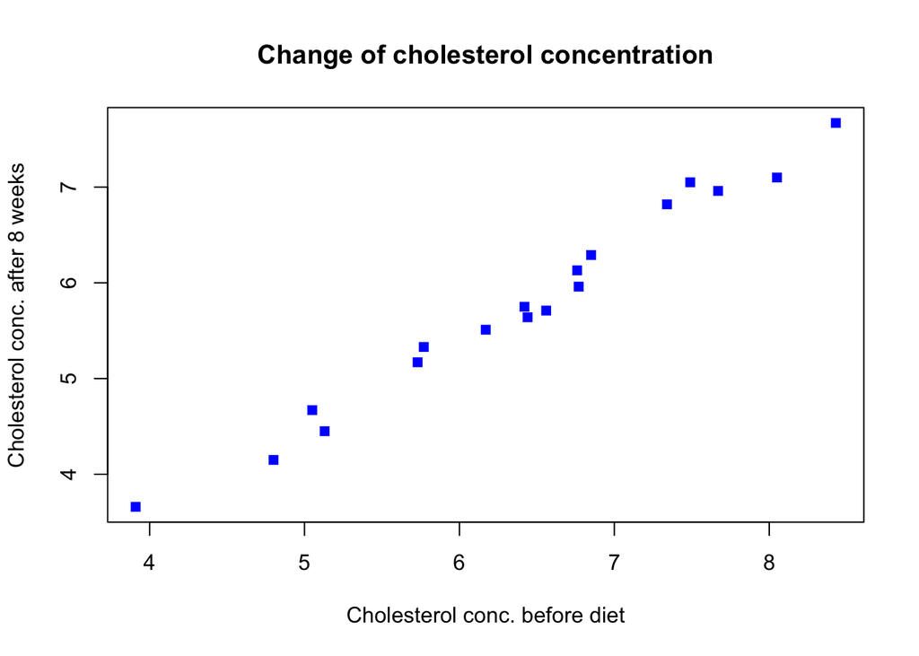

```r
plot(After8weeks ~ Before, data = data_chol,
xlab = "Cholesterol conc. before diet",
ylab = "Cholesterol conc. after 8 weeks",
main = "Change of cholesterol concentration",
pch = 15, col = "blue")
```

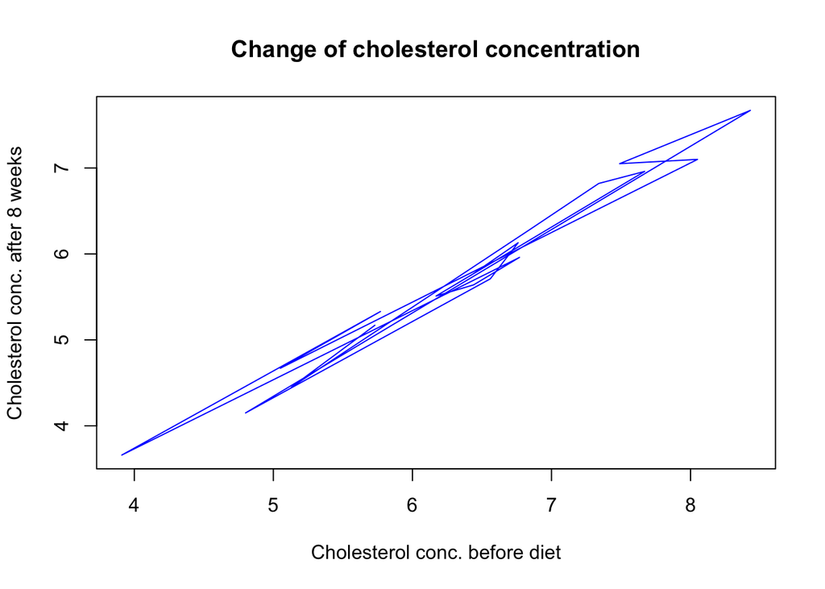

```r
plot(After8weeks ~ Before, data = data_chol,
xlab = "Cholesterol conc. before diet",
ylab = "Cholesterol conc. after 8 weeks",
main = "Change of cholesterol concentration",
pch = 15, col = "blue", type = 'l')
```

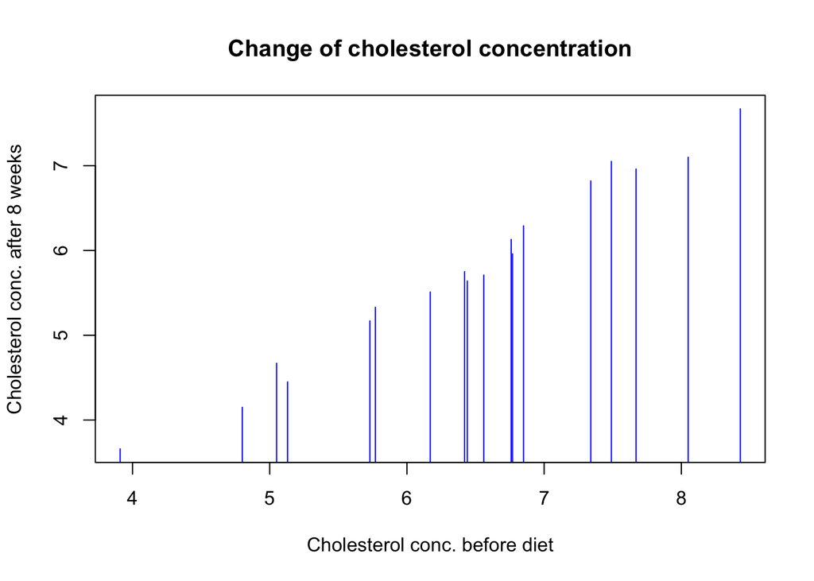

```r
plot(After8weeks ~ Before, data = data_chol,
xlab = "Cholesterol conc. before diet",
ylab = "Cholesterol conc. after 8 weeks",
main = "Change of cholesterol concentration",
pch = 15, col = "blue", type = 'h')
```

Using the `type = 'l'` leads to a surprising problem - instead of an expected zig-zag line connecting the points we gat a weird squiggly bunch of loops. What should be done to the data to retrieve a proper line plot, like the one below?

**Output**

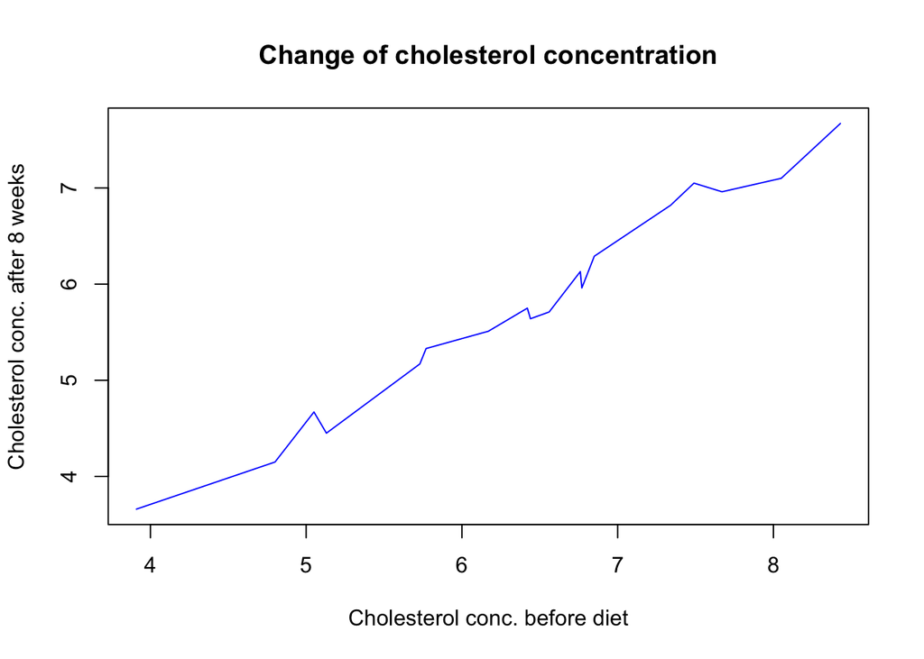

```r
plot(After8weeks ~ Before, data = data_chol[order(data_chol$Before),],
xlab = "Cholesterol conc. before diet",
ylab = "Cholesterol conc. after 8 weeks",
main = "Change of cholesterol concentration",
pch = 15, col = "blue", type = 'l')
```

## 3 Using colours in R plots

**EXERCISE 4:** Colours and shapes on a plot can be changed at will. Try to experiment in order to recreate the below plot. Note: you have to creat your own data or input it directly into the plotting function. Information about colour codes can be found here: http://derekogle.com/NCGraphing/resources/colors - in summary, you can choose them by indicating their names (e.g. `"hotpink"`) or specifying a colour’s name in a hexadecimal number system (e.g. `"#AA6574"`).

**Output**

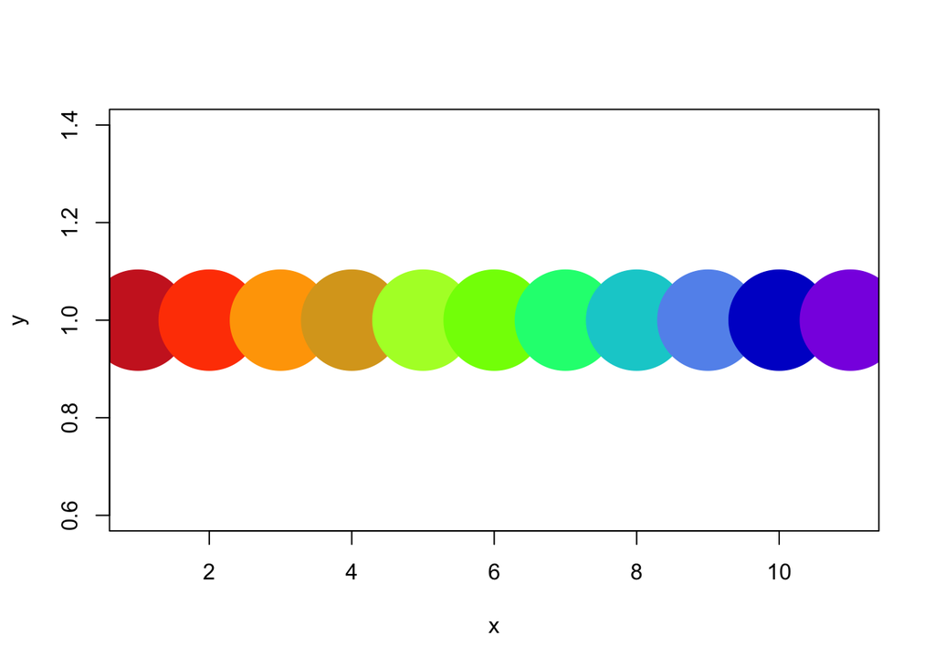

```r
N <- 11
plot(1:N, rep(1, N), cex = 10, pch = 19,
     col = c('firebrick3', 'orangered', 'orange', 'goldenrod',
             'greenyellow', 'chartreuse', 'springgreen', 'darkturquoise',
             'cornflowerblue', 'mediumblue', 'blueviolet'),
     xlab = 'x', ylab = 'y')
```

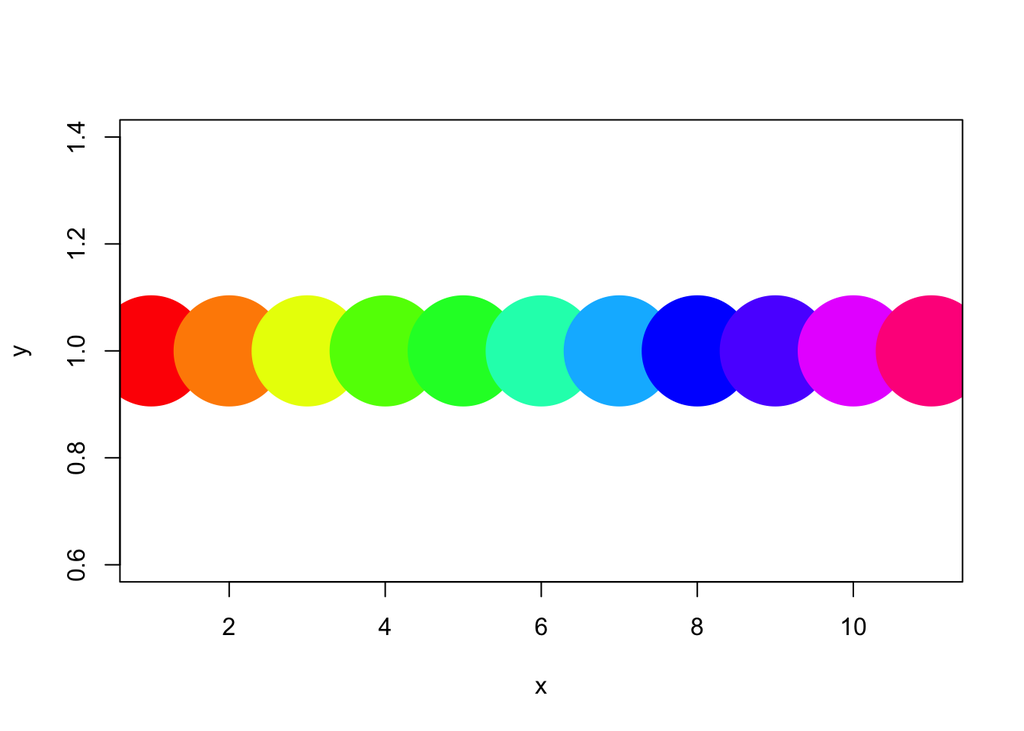

```r
### OR for automated colour generation

plot(1:N, rep(1, N), cex = 10, pch = 19,
     col = rainbow(N),
     xlab = 'x', ylab = 'y')
```

## 4 Assigning colours to variables

**EXERCISE 5:** The below plot uses colours to cod the age groups in our data - try to recreate this plot by linking the `col` option to the relevant data variable. What key is ues to choose specific colours on the plot?

**Output**

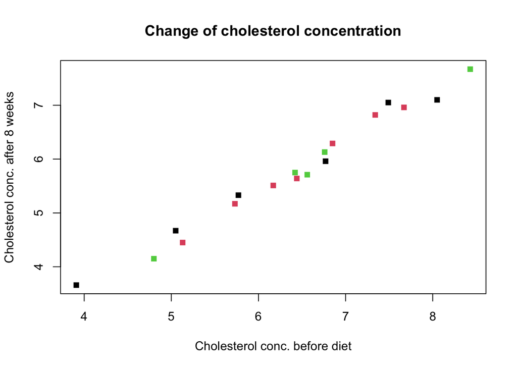

```r
plot(After8weeks ~ Before, data = data_chol,
xlab = "Cholesterol conc. before diet",
ylab = "Cholesterol conc. after 8 weeks",
main = "Change of cholesterol concentration",
pch = 15, col = data_chol$AgeGroup)
```

**EXERCISE 6:** If you would like to use non-default colours here, you have to use the fact that levels o a categorical variable in R (e.g., `AgeGroup`) are coded as integers, and hence can be treated as indices selecting values from a vector of colour names/codes:

**Output**

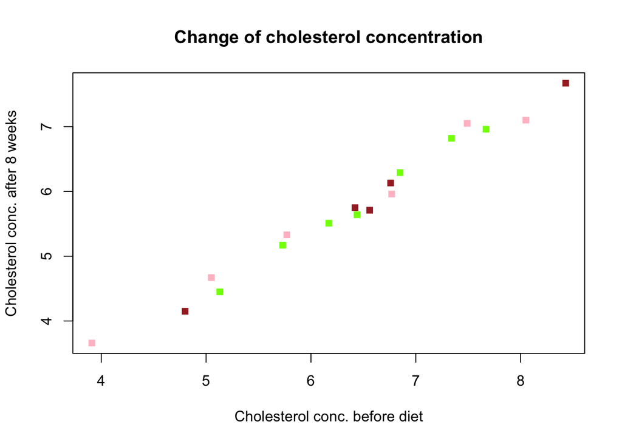

```r
plot(After8weeks ~ Before, data = data_chol,
xlab = "Cholesterol conc. before diet",
ylab = "Cholesterol conc. after 8 weeks",
main = "Change of cholesterol concentration",
pch = 15, col = c('pink', 'chartreuse', 'brown')[data_chol$AgeGroup])
```

## 5 Histogram

Histogram is a useful and frequently used type of plot - it can be generated using the `hist()` function.

**EXERCISE 7:** Create a histogram of 50 ranom samples from a normal distribution with mean 20 and standard deviation 4 (you may want to use the following call `rnorm(50, 20, 4)`). **Output**

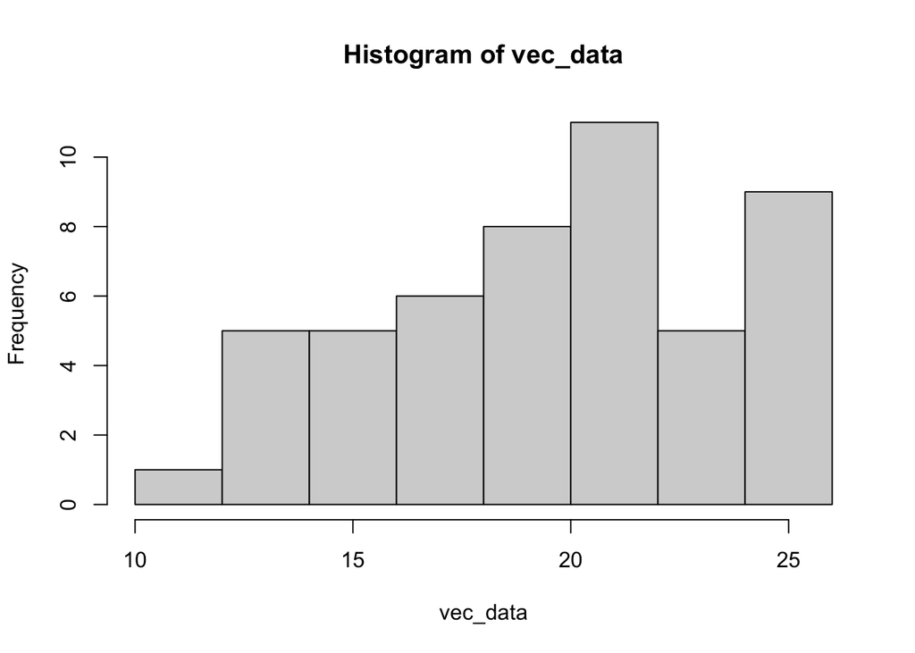

```r
set.seed(123456789)
vec_data <- rnorm(50, 20, 4)
hist(vec_data)
```

Histogram does not have one colour parameter - each rectangle has a border and its filling. Consulting `?hist()` check how to reproduce the below version of a histogram.

**Output**

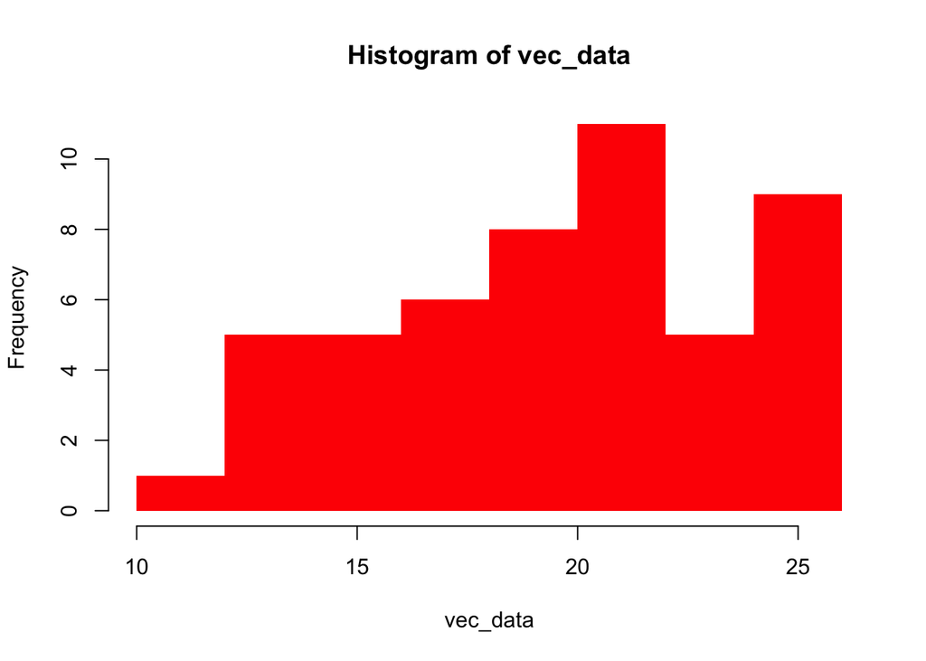

```r
set.seed(123456789)
vec_data <- rnorm(50, 20, 4)
hist(vec_data, col = 'red', border = NA)
```

**EXERCISE 8:** Redo the histogram by increasing the number of binning intervals. **Output** (example)

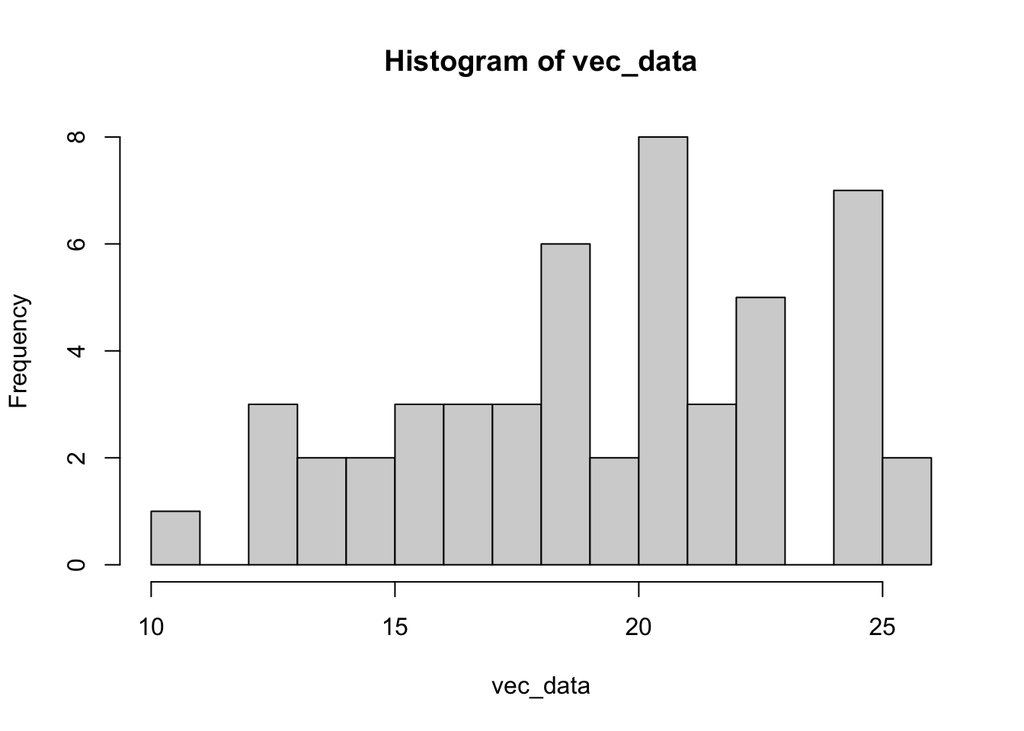

```r
set.seed(123456789)
vec_data <- rnorm(50, 20, 4)
hist(vec_data, 20)
```

**EXERCISE 9:** instead of a histogram, distributional data can be presented using a smoothed density of data (*kernel density*). You can use the built-in function `density()` to produce such curve, and it can be overlaid on an existing plot using the `lines()` function (similarly, to the `points()` function overlaying points, the `lines()` function does not create a new plot but adds lines to an existing plot ). Try to recreate the above histogram adding to it an overlaid density line: **Output** (example)

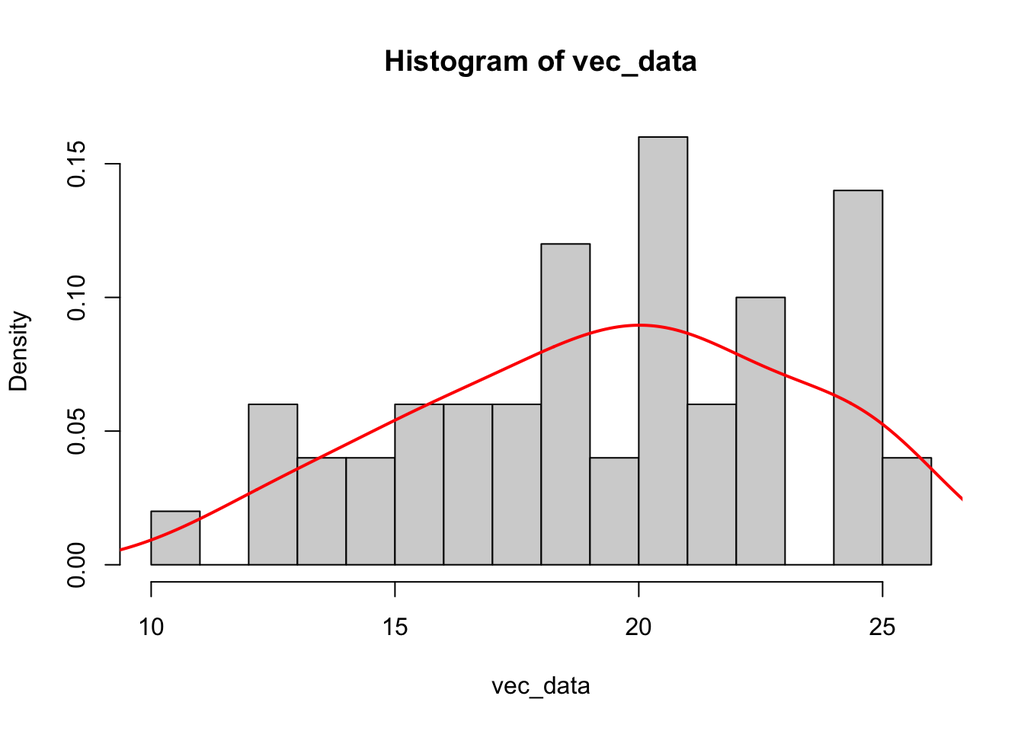

```r
set.seed(123456789)
vec_data <- rnorm(50, 20, 4)
hist(vec_data, 20, freq = F)
lines(density(vec_data), col = 'red', lwd = 2)
```

R plots generated by the basic function can be modified in many ways, to adjust their appearance to particular needs. A number of parameters can be set inside the `plot()` function, but others can be set using a special `par()` function.

**EXERCISE 10:** The plotting area can be modified by setting the limits of the axes - to achieve this modify the `ylim` and `xlim` arguments, they take vectors of length 2 as values. **Output**

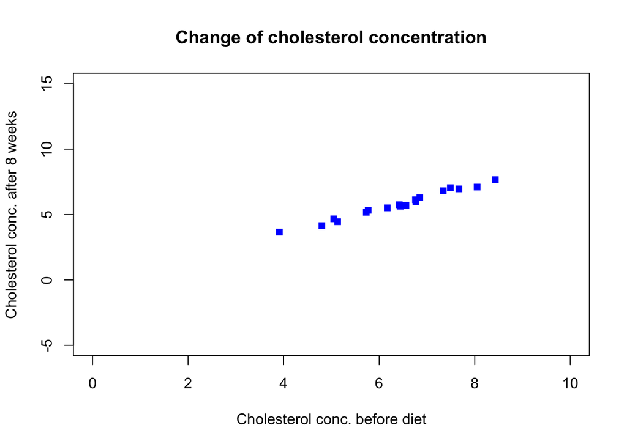

```r
plot(After8weeks ~ Before, data = data_chol,
xlab = "Cholesterol conc. before diet",
ylab = "Cholesterol conc. after 8 weeks",
main = "Change of cholesterol concentration",
pch = 15, col = "blue",
xlim = c(0, 10), ylim = c(-5, 15))
```

Such option becomes especially useful when plotting custom curves, that need to be displayed in some speciic range. Compare the two below plots:

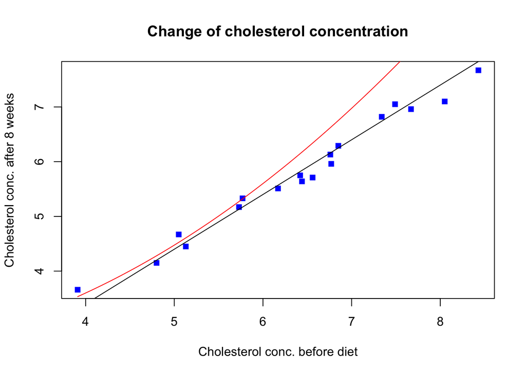

```r
plot(After8weeks ~ Before, data = data_chol,
xlab = "Cholesterol conc. before diet",
ylab = "Cholesterol conc. after 8 weeks",
main = "Change of cholesterol concentration",
pch = 15, col = "blue")

curve(-0.6 + x, add = T)
curve(2.6 - 0.25*x + 0.125*x^2, add = T, col = 'red')
```

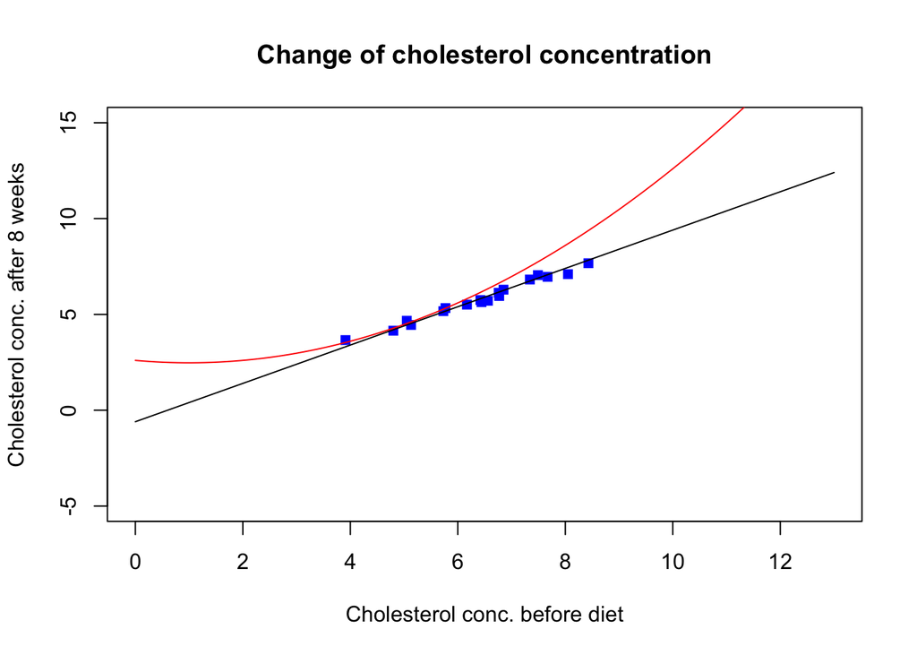

```r
plot(After8weeks ~ Before, data = data_chol,
xlab = "Cholesterol conc. before diet",
ylab = "Cholesterol conc. after 8 weeks",
main = "Change of cholesterol concentration",
pch = 15, col = "blue",
xlim = c(0, 13), ylim = c(-5, 15))

curve(-0.6 + x, add = T)
curve(2.6 - 0.25*x + 0.125*x^2, add = T, col = 'red')
```

**EXERCISE 11:** Try applying similar modification to our final histogram, to avoid automativ selection of x-axis ends (which slightly misses the limits o actual data).

**Output** (example)

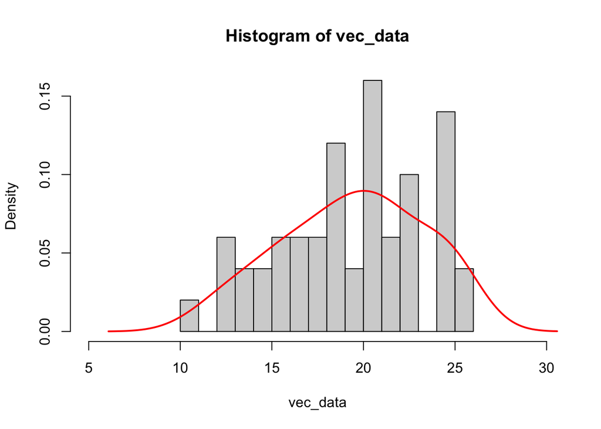

```r
set.seed(123456789)
vec_data <- rnorm(50, 20, 4)
hist(vec_data, 20, freq = F, xlim = c(5, 30))
lines(density(vec_data), col = 'red', lwd = 2)
```

**EXERCISE 12:** The plotting function options can also be used to change the type of axes to logged - we can achieve this in two ways, resulting in two different ways of presentation. The simplest is to use the `log` option in the `plot()` function: **Output**

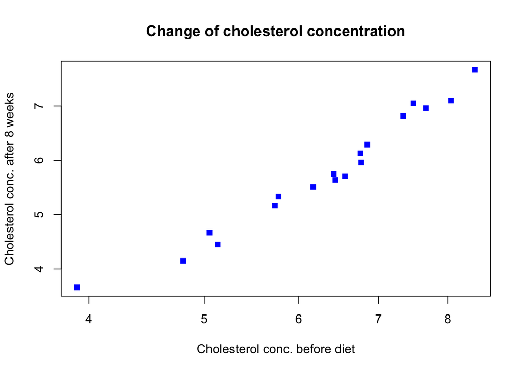

```r
plot(After8weeks ~ Before, data = data_chol,
xlab = "Cholesterol conc. before diet",
ylab = "Cholesterol conc. after 8 weeks",
main = "Change of cholesterol concentration",
pch = 15, col = "blue", log = "x")
```

However, you can also directly log the data while plotting it (how would you achieve this?). **Output**

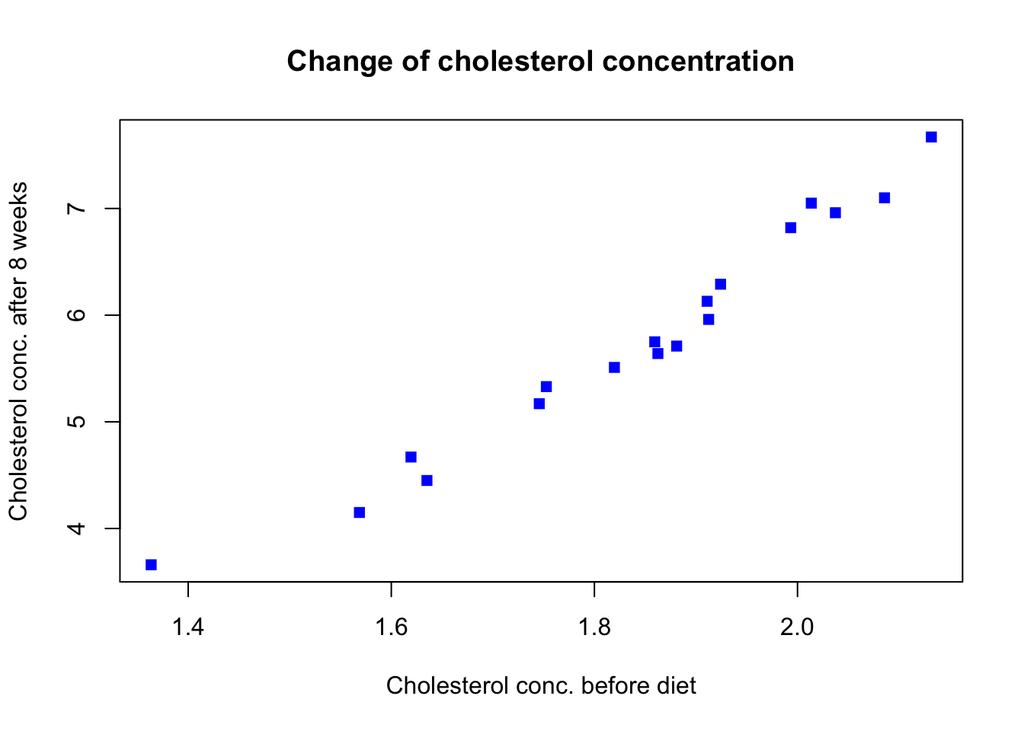

```r
plot(After8weeks ~ log(Before), data = data_chol,
xlab = "Cholesterol conc. before diet",
ylab = "Cholesterol conc. after 8 weeks",
main = "Change of cholesterol concentration",
pch = 15, col = "blue")
```

The plots look similar - but there is one fundamental difference - what is it? What type of log was used in these plots?

**EXERCISE 13:** In order to modify plot parameters such as its margins - we have to use the `par()` function, and we should modify specific parameters in it. Be aware, that the setting chosen will affect any future plot produced in a given session of R. Try using the `mai` option (which specifies distances in inches) or `mar` option (which specify distances in lines of text) to change the plot margins (each of these options takes a vector with 4 elements, the margins of bottom, left, top and right edge). The below picture demonstrates how the margin parameters are interpreted with respect to a plotting area:

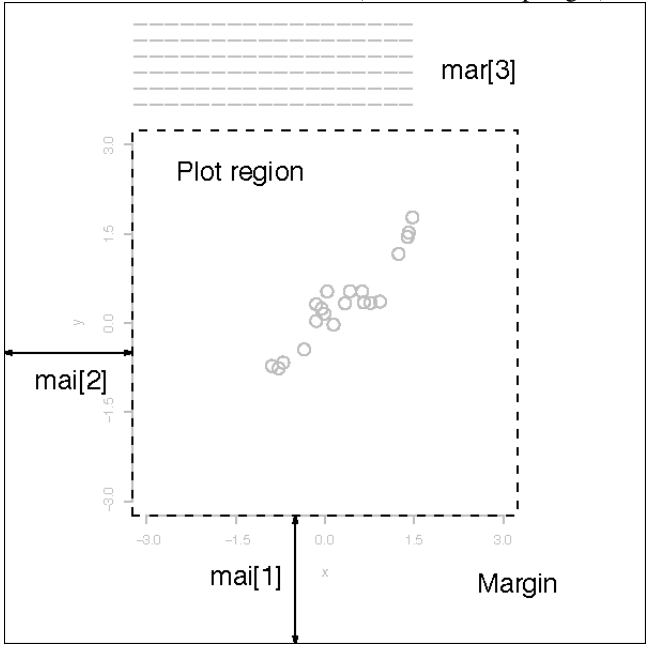

**Output**

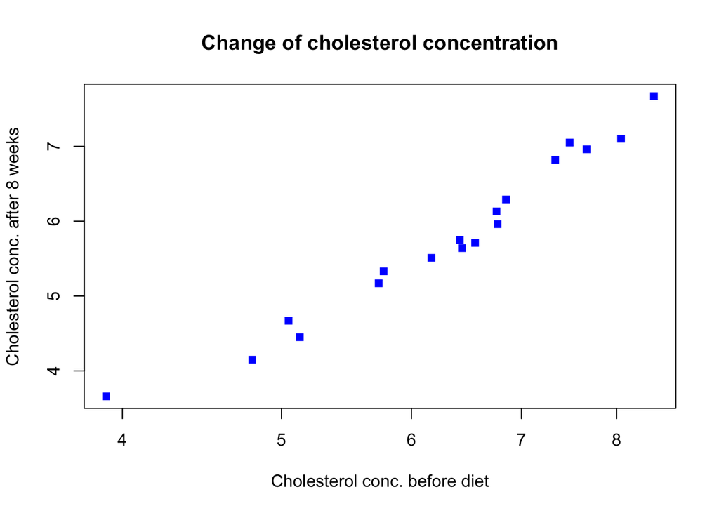

```r
plot(After8weeks ~ Before, data = data_chol,
xlab = "Cholesterol conc. before diet",
ylab = "Cholesterol conc. after 8 weeks",
main = "Change of cholesterol concentration",
pch = 15, col = "blue", log = "x")
```

```r
par(mar = c(7,10,10,10))
plot(After8weeks ~ Before, data = data_chol,
xlab = "Cholesterol conc. before diet",
ylab = "Cholesterol conc. after 8 weeks",
main = "Change of cholesterol concentration",
pch = 15, col = "blue", log = "x")
```

[output not shown]

If at any stage you use the `par()` function and loose track of what parameters have been modified and which haven’t (or - another function happens to modify some graphical parameters beyond your control) you can easily reset the plotting standard output to the default graphical parameters. Just run:

```r
dev.off()
```

which will close and reset the active (screen) plotting output.

## 7 Using `ggplot2` - introduction

Control over the graphical parameters in the `plot()` function is rudimentary. The **ggplot2** package gives much more control over how the plots are made and built. The **ggplot2** package is based on so called graphics grammar, a set of rules describing the visual appearance of a plot:

- linking of data to specific elements of a plot (so called **mapping**) is separated from its actual appearance (i.e., **aesthetics**);
- the plot has a layered structure, with latter elements appearing on top of the former ones;
- if possible all plot elements should be built on the go, inside of the plotting code, without the need of modifying/transforming the original data.

A simple *ggplot2* graph may be structured as follows:

```r
mygraph <- ggplot(data = MYDATA,
                  mapping = aes(x = VAR1, y = VAR2, ...)) +
  geom_1(OPTIONS) +
  geom_2(OPTIONS)

plot(mygraph)

graph2 <- mygraph + geom_3
plot(graph2)
```

Calling the `ggplot()` function may be used only to create an object of class `ggplot`, without displaying the actual graph. Such object will contain the data and its mappings to specific elements of the final plot. To display it, we need additional function from the `geom_...` family, which add specific visual elements to the defined mappings (e.g. `geom_point` adds scatterpoints, `geom_hist` forms a histogram). Subsequent elements can be concatenated using the `+` operator. other elements that can be added to the plot using `+` are display and aesthetic rules, e.g. `theme()`, which describe the appearance of non-data elements of a plot.

Load the `ggplot2` - if you don’t have it use `install.packages()` to install it.

```r
# install.packages('ggplot2')
library(ggplot2)
```

## 8 `ggplot2` scatterplot

**EXERCISE 14:** Make a scatterplot similar to one of the previous excersises, mapping the concentrations of cholesterol on the x and y axes. Use blue squares as points. You may want to use the `cex` option to increase the default symbol size (`cex` defines a multiplicative coefficient, that increases or decreases plot elements given number of times).

**Output**

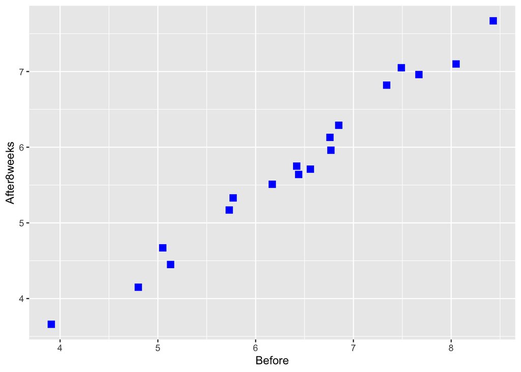

```r
plot1 <- ggplot(data = data_chol, mapping = aes(x = Before, y = After8weeks)) +
  geom_point(color = 'blue', shape = 15, cex = 3)
plot1
```